# **Ingeniería de Características, Proyecto Integrador: Contando una historia con los datos de marginacion municipal en Sonora, 2010-2020**

Santiago Francisco Robles Tamayo

06/11/2022

# **Introducción**

El trabajo final será compartido en formato HTML, junto con su respectivo markdown, un repositorio de GitHub con acceso libre.

# **Primera parte**

Instrucción: *Un script o libreta que descargue datos de al menos dos fuentes diferentes, y que genere un archivo texto con la descripción de las fuentes, las fechas de descarga y de ser posible la descripción (o enlaces) que expliquen la naturaleza de los datos descargados. Si los datos venían sin explicación, agregar la explicación propia para simplificar el proceso.*

#### **Descarga de librerías**

```r
# install.packages("tidyverse") # Para manipulación de datos y otras muchas funciones
# install.packages("htmltools") # Para agregar características html en el caso de mapas interactivos
# install.packages("htmlwidgets") # Para guardar nuestro mapa como html
# install.packages("rgdal")# Para el manejo de archivos geográficos
# install.packages("rgeos") # Para el manejo de archivos geográficos
# install.packages("rcartocolor") # Paquete de paleta de colores
# install.packages("leaflet") #  Paquete para crear mapas interactivos

library(tidyverse) # Libreta para el arreglo de datos
library(htmltools) # Libreta para convertir objetos a HTML
library(htmlwidgets) # Libreta para convertir objetos a HTML
library(rgdal) #Libreta de datos georeferenciados
library(rgeos) #Libreta para mapas
library(rcartocolor) # Paleta de colores
library(leaflet) # Libreta para hacer mapas interactivos
```

A través del uso de la página web de la Comisión Nacional de Población (CONAPO), se descargaron los datos referentes al índice de marginación a nivel municipal para todas las entidades de la república, de 2010 y 2020. Para esto, se usaron enlaces de CONAPO con terminación *.xls*, por lo que fue necesario instalar la paquetería *readxl* y activar la librería homónima. Después, se usaron los comandos *tempfile()* y *read_excel()* (Stackoverflow, 2016) para generar un dataframe que contiene los datos referentes a marginación de 2020, llamado *data2020_1*.

#### **Descarga de bases de datos**

```r
# install.packages("readxl")
library(readxl)

url_2020 = "http://www.conapo.gob.mx/work/models/CONAPO/Marginacion/Datos_Abiertos/Municipio/IMM_2020.xls"
p1f <- tempfile()
download.file(url_2020, p1f, mode="wb")
data2020_1 <- read_excel(path = p1f, sheet = 2)

View(data2020_1)

# Cargamos diccionario
Diccionario <- read_excel(path = p1f,
                                 sheet = "Diccionario", range = "a3:b23")



## Estructura
str(data2020_1)
```

```
## tibble [2,469 x 17] (S3: tbl_df/tbl/data.frame)
##  $ CVE_ENT : chr [1:2469] "01" "01" "01" "01" ...
##  $ NOM_ENT : chr [1:2469] "Aguascalientes" "Aguascalientes" "Aguascalientes" "Aguascalientes" ...
##  $ CVE_MUN : chr [1:2469] "01001" "01002" "01003" "01004" ...
##  $ NOM_MUN : chr [1:2469] "Aguascalientes" "Asientos" "Calvillo" "Cosío" ...
##  $ POB_TOT : num [1:2469] 948990 51536 58250 17000 129929 ...
##  $ ANALF   : num [1:2469] 1.64 3.53 4.49 3.14 2.38 ...
##  $ SBASC   : num [1:2469] 20.4 33.9 42.5 27.7 26.7 ...
##  $ OVSDE   : num [1:2469] 0.105 2.65 0.365 0.713 0.277 ...
##  $ OVSEE   : num [1:2469] 0.113 0.486 0.517 0.577 0.355 ...
##  $ OVSAE   : num [1:2469] 0.379 0.858 0.801 0.66 0.86 ...
##  $ OVPT    : num [1:2469] 0.591 1.352 1.04 1.031 1.313 ...
##  $ VHAC    : num [1:2469] 10.3 22.9 19.2 22.7 16.4 ...
##  $ PL.5000 : num [1:2469] 7.52 78.22 51.3 65.47 37.16 ...
##  $ PO2SM   : num [1:2469] 54.2 78.6 79.3 81.7 56.7 ...
##  $ IM_2020 : num [1:2469] 60.3 56.5 57.1 57.1 59 ...
##  $ GM_2020 : chr [1:2469] "Muy bajo" "Muy bajo" "Muy bajo" "Muy bajo" ...
##  $ IMN_2020: num [1:2469] 0.945 0.885 0.893 0.894 0.924 ...
```

```r
view(Diccionario)
## Valores únicos
unique(data2020_1$NOM_ENT)
```

```
##  [1] "Aguascalientes"                  "Baja California"
##  [3] "Baja California Sur"             "Campeche"
##  [5] "Coahuila de Zaragoza"            "Colima"
##  [7] "Chiapas"                         "Chihuahua"
##  [9] "Ciudad de México"                "Durango"
## [11] "Guanajuato"                      "Guerrero"
## [13] "Hidalgo"                         "Jalisco"
## [15] "México"                          "Michoacán de Ocampo"
## [17] "Morelos"                         "Nayarit"
## [19] "Nuevo León"                      "Oaxaca"
## [21] "Puebla"                          "Querétaro"
## [23] "Quintana Roo"                    "San Luis Potosí"
## [25] "Sinaloa"                         "Sonora"
## [27] "Tabasco"                         "Tamaulipas"
## [29] "Tlaxcala"                        "Veracruz de Ignacio de la Llave"
## [31] "Yucatán"                         "Zacatecas"
```

```r
unique(data2020_1$GM_2020)
```

```
## [1] "Muy bajo" "Medio"    "Bajo"     "Alto"     "Muy alto"
```

```r
## Niveles
levels=c("Muy bajo", "Bajo", "Medio", "Alto", "Muy alto") # Definimos los niveles del GM


# Se filtran los municipios de Sonora, se ordenan los niveles del GM
marginacion_municipal_sonora_2020 <- data2020_1 %>%
  filter(NOM_ENT=="Sonora") %>% mutate(GM_2020=factor(GM_2020,levels))
marginacion_municipal_sonora_2020 %>% group_by(GM_2020) %>% summarise(n())
```

```
## # A tibble: 4 x 2
##   GM_2020  `n()`
##   <fct>    <int>
## 1 Muy bajo    50
## 2 Bajo        17
## 3 Medio        4
## 4 Alto         1
```

```r
marginacion_municipal_sonora_2020
```

```
## # A tibble: 72 x 17
##    CVE_ENT NOM_ENT CVE_MUN NOM_MUN POB_TOT ANALF SBASC OVSDE OVSEE  OVSAE   OVPT
##    <chr>   <chr>   <chr>   <chr>     <dbl> <dbl> <dbl> <dbl> <dbl>  <dbl>  <dbl>
##  1 26      Sonora  26001   Aconchi    2563  2.69  37.1 0.780 0.858 0.702   0.312
##  2 26      Sonora  26002   Agua P~   91929  1.49  26.0 0.204 1.04  0.619   0.946
##  3 26      Sonora  26003   Alamos    24976  8.11  41.7 7.85  4.09  5.19   10.8
##  4 26      Sonora  26004   Altar      9492  3.43  35.1 1.14  0.933 1.03    1.02
##  5 26      Sonora  26005   Arivec~    1177  3.27  45.9 0.257 3.25  0.0855  1.88
##  6 26      Sonora  26006   Arizpe     2788  2.81  41.5 0.683 0.611 0.611   1.62
##  7 26      Sonora  26007   Atil        626  2.03  33.8 1.12  0.479 0.799   0.639
##  8 26      Sonora  26008   Bacadé~     979  4.22  50.5 0.613 0.102 0.102   1.74
##  9 26      Sonora  26009   Bacano~     759  5.15  53.4 1.47  0.267 0.401   0.668
## 10 26      Sonora  26010   Bacerac    1221  3.61  43.6 2.87  1.56  0.410   0.820
## # ... with 62 more rows, and 6 more variables: VHAC <dbl>, PL.5000 <dbl>,
## #   PO2SM <dbl>, IM_2020 <dbl>, GM_2020 <fct>, IMN_2020 <dbl>
```

Dado que los datos de marginación a nivel municipal para todas las entidades federativas están separados por año, se ejecutó el mismo procedimiento, por separado, para el año 2010, generando un nuevo dataframe nombrado *data2010*. A diferencia de *data2020_1*, a este dataframe no se le colocó “_1” en su nombre por motivos descritos posteriormente.

```r
# install.packages("readxl")
library(readxl)

url_2010 = "http://www.conapo.gob.mx/work/models/CONAPO/Marginacion/Datos_Abiertos/Municipio/IMM_DP2_2010.xlsx"
p1f <- tempfile()
download.file(url_2010, p1f, mode="wb")
data2010 <- read_excel(path = p1f, sheet = 2)

View(data2010)

## Estructura
str(data2010)
```

```
## tibble [2,456 x 17] (S3: tbl_df/tbl/data.frame)
##  $ CVE_ENT : chr [1:2456] "01" "01" "01" "01" ...
##  $ NOM_ENT : chr [1:2456] "Aguascalientes" "Aguascalientes" "Aguascalientes" "Aguascalientes" ...
##  $ CVE_MUN : chr [1:2456] "01001" "01002" "01003" "01004" ...
##  $ NOM_MUN : chr [1:2456] "Aguascalientes" "Asientos" "Calvillo" "Cosío" ...
##  $ POB_TOT : num [1:2456] 797010 45492 54136 15042 99590 ...
##  $ ANALF   : num [1:2456] 2.59 5.54 6.19 4.35 3.76 ...
##  $ SBASC   : num [1:2456] 31.2 50.1 57.2 43.4 43.2 ...
##  $ OVSDE   : num [1:2456] 0.501 5.77 0.822 2.184 1.277 ...
##  $ OVSEE   : num [1:2456] 0.313 2.14 0.874 2.004 1.167 ...
##  $ OVSAE   : num [1:2456] 0.766 2.047 1.797 0.293 1.434 ...
##  $ OVPT    : num [1:2456] 1.42 2.59 2.42 3.26 2.59 ...
##  $ VHAC    : num [1:2456] 25.2 45.3 39.8 44.7 39.2 ...
##  $ PL.5000 : num [1:2456] 8.73 100 50.76 100 45.17 ...
##  $ PO2SM   : num [1:2456] 29.9 59.5 60.1 54.8 31.2 ...
##  $ IM_2010 : num [1:2456] 37.9 33.4 34.7 34.1 36 ...
##  $ GM_2010 : chr [1:2456] "Muy bajo" "Bajo" "Bajo" "Bajo" ...
##  $ IMN_2010: num [1:2456] 0.925 0.816 0.848 0.834 0.88 ...
```

```r
view(Diccionario)
## Valores únicos
unique(data2010$NOM_ENT)
```

```
##  [1] "Aguascalientes"                  "Baja California"
##  [3] "Baja California Sur"             "Campeche"
##  [5] "Coahuila de Zaragoza"            "Colima"
##  [7] "Chiapas"                         "Chihuahua"
##  [9] "Distrito Federal"                "Durango"
## [11] "Guanajuato"                      "Guerrero"
## [13] "Hidalgo"                         "Jalisco"
## [15] "México"                          "Michoacán de Ocampo"
## [17] "Morelos"                         "Nayarit"
## [19] "Nuevo León"                      "Oaxaca"
## [21] "Puebla"                          "Querétaro"
## [23] "Quintana Roo"                    "San Luis Potosí"
## [25] "Sinaloa"                         "Sonora"
## [27] "Tabasco"                         "Tamaulipas"
## [29] "Tlaxcala"                        "Veracruz de Ignacio de la Llave"
## [31] "Yucatán"                         "Zacatecas"
```

```r
unique(data2010$GM_2010)
```

```
## [1] "Muy bajo" "Bajo"     "Medio"    "Alto"     "Muy alto"
```

```r
## Niveles
levels=c("Muy bajo", "Bajo", "Medio", "Alto", "Muy alto") # Definimos los niveles del GM


# Se filtran los municipios de Sonora, se ordenan los niveles del GM
marginacion_municipal_sonora_2010 <- data2010 %>%
  filter(NOM_ENT=="Sonora") %>% mutate(GM_2010=factor(GM_2010,levels))
marginacion_municipal_sonora_2010 %>% group_by(GM_2010) %>% summarise(n())
```

```
## # A tibble: 4 x 2
##   GM_2010  `n()`
##   <fct>    <int>
## 1 Muy bajo    41
## 2 Bajo        26
## 3 Medio        4
## 4 Alto         1
```

```r
marginacion_municipal_sonora_2010
```

```
## # A tibble: 72 x 17
##    CVE_ENT NOM_ENT CVE_MUN NOM_MUN     POB_TOT ANALF SBASC  OVSDE  OVSEE   OVSAE
##    <chr>   <chr>   <chr>   <chr>         <dbl> <dbl> <dbl>  <dbl>  <dbl>   <dbl>
##  1 26      Sonora  26001   Aconchi        2637  4.03  49.8  1.87   0.304  0.0762
##  2 26      Sonora  26002   Agua Prieta   79138  2.05  38.9  0.361  2.97   0.948
##  3 26      Sonora  26003   Alamos        25848 11.6   54.9 12.4    7.28  11.0
##  4 26      Sonora  26004   Altar          9049  4.35  51.1  3.04   1.01   4.37
##  5 26      Sonora  26005   Arivechi       1253  5.14  56.3  2.78  10.4    0
##  6 26      Sonora  26006   Arizpe         3037  3.77  52.6  2.52   3.21   4.34
##  7 26      Sonora  26007   Atil            625  2.62  46.8  0.48   0.8    1.28
##  8 26      Sonora  26008   Bacadéhuac~    1252  4.87  59.4  2.49   0.240  0
##  9 26      Sonora  26009   Bacanora        784  7.60  62.6  4.09   4.61   1.02
## 10 26      Sonora  26010   Bacerac        1467  3.94  55.1  1.57   3.23   1.93
## # ... with 62 more rows, and 7 more variables: OVPT <dbl>, VHAC <dbl>,
## #   PL.5000 <dbl>, PO2SM <dbl>, IM_2010 <dbl>, GM_2010 <fct>, IMN_2010 <dbl>
```

# **Segunda parte**

Instrucción: *Una libreta o script que transforme y utilice los datos de acuerdo a su tipo, selecciones la información que se desea utilizar y se generen los Dataframes necesarios.*

El siguiente paso consistió en arreglar los dataframes previamente creados para tener sólo los datos de Sonora. Se optó por tener tres dataframes: en el primero, los datos de ambos años para el estado de Sonora en un sólo conjunto; el segundo, los datos de marginación en Sonora en 2010; y el tercero, los datos de marginación en Sonora en 2020. Sin embargo, para lograrlo fue necesaria la creación de otros bloques de datos.

# **Dataframe del total de datos de marginación en Sonora: 2010 y 2010**

```r
 library(tidyverse)
 library(dplyr)

data2020 <- data2020_1 %>%
   select(CVE_MUN, POB_TOT, ANALF, SBASC, OVSDE, OVSEE, OVSAE, OVPT, VHAC, PL.5000, PO2SM, IM_2020, GM_2020, IMN_2020)

 total <- left_join(data2010, data2020, by = "CVE_MUN")
View(total)
```

A partir de este último bloque de datos, se creó el data frame *total_son*, que contiene únicamente los datos de marginación del estado de Sonora, por municipio, para 2010 y 2020. Esto fue posible nombrando un nuevo objeto que sólo considere los datos en los reglones que contengan el número *26* (clave entidad de Sonora) de la columna *CVE_ENT* del dataframe *total*.

```r
total_son <- total[total$CVE_ENT == '26',]
View(total_son)
total_son
```

```
## # A tibble: 72 x 30
##    CVE_ENT NOM_ENT CVE_MUN NOM_MUN     POB_TOT.x ANALF.x SBASC.x OVSDE.x OVSEE.x
##    <chr>   <chr>   <chr>   <chr>           <dbl>   <dbl>   <dbl>   <dbl>   <dbl>
##  1 26      Sonora  26001   Aconchi          2637    4.03    49.8   1.87    0.304
##  2 26      Sonora  26002   Agua Prieta     79138    2.05    38.9   0.361   2.97
##  3 26      Sonora  26003   Alamos          25848   11.6     54.9  12.4     7.28
##  4 26      Sonora  26004   Altar            9049    4.35    51.1   3.04    1.01
##  5 26      Sonora  26005   Arivechi         1253    5.14    56.3   2.78   10.4
##  6 26      Sonora  26006   Arizpe           3037    3.77    52.6   2.52    3.21
##  7 26      Sonora  26007   Atil              625    2.62    46.8   0.48    0.8
##  8 26      Sonora  26008   Bacadéhuac~      1252    4.87    59.4   2.49    0.240
##  9 26      Sonora  26009   Bacanora          784    7.60    62.6   4.09    4.61
## 10 26      Sonora  26010   Bacerac          1467    3.94    55.1   1.57    3.23
## # ... with 62 more rows, and 21 more variables: OVSAE.x <dbl>, OVPT.x <dbl>,
## #   VHAC.x <dbl>, PL.5000.x <dbl>, PO2SM.x <dbl>, IM_2010 <dbl>, GM_2010 <chr>,
## #   IMN_2010 <dbl>, POB_TOT.y <dbl>, ANALF.y <dbl>, SBASC.y <dbl>,
## #   OVSDE.y <dbl>, OVSEE.y <dbl>, OVSAE.y <dbl>, OVPT.y <dbl>, VHAC.y <dbl>,
## #   PL.5000.y <dbl>, PO2SM.y <dbl>, IM_2020 <dbl>, GM_2020 <chr>,
## #   IMN_2020 <dbl>
```

# **Generar un archivo csv del data frame**

Se utiliza el siguiente comando para generar un archivo *csv* a partir del data frame *total_son*.

```r
#write.csv(total_son, "C:\\Users\\santi\\Documents\\MCD_UNISON\\PRIMER_SEMESTRE\\IngenieriaDeCaracteristicas\\data_total_son.csv", row.names=FALSE)
```

# **Datos de marginacion en Sonora por año**

Para generar dos dataframes de marginación municipal en Sonora, por año, también se creó un nuevo objeto que sólo considere los datos en los reglones que contengan el número *26* (clave entidad de Sonora) de la columna *CVE_ENT* de las bases *data2020_1* y *data2010*.

```r
data2020_son <- data2020_1[data2020_1$CVE_ENT == '26',]
View(data2020_son)

data2010_son <- data2010[data2010$CVE_ENT == '26',]
View(data2010_son)
```

# **Otras opciones para generar un dataframe**

Dentro de otra posibles alternativas para generar tidydata de los datos de marginación en Sonora, se encuentran las siguientes. Una consiste en combinar todas las columnas los datos de 2010 y 2020, de todos los municipios y estados; no era conveniente porque hubiese implicado el borrar columnas repetidas. Por otro lado, el comando *merge*, capaz de seleccionar un conjunto de columnas de un dataframe para anexarlo a otro, pudo haber combinado las columnas necesarias para tener en un sólo marco de datos la información nacional, por estados y municipios, de ambos años.

```r
# # merge two data frames by ID
# total <- merge(data_2020, data_2010, by="CVE_ENT")
# View(total)
#
# merge(x = data_2020, y = data_2010[ , c("POB_TOT", "ANALF", "SBASC", "OVSDE", "OVSEE", "OVSAE", "OVPT", "VHAC", "PL.5000", "PO2SM", "IM_2010", "GM_2010", "IMN_2010")], by = "CVE_MUN")
```

# **Diccionario de variables**

Instrucción: *Un diccionario de datos por cada dataframe*

A continuación, se nombró un diccionario de datos único para las tres dataframes de interés, pues todas manejan las mismas columnas o variables. Sólo en el dataframe *total_son* hay una pequeña diferencia: son las mismas variables, pero se distinguen con *.x* al final las que corresponden al año 2010, y con *.y* al final aquellas que son del año 2020.

- *CVE_ENT*: Clave única por entidad federativa de México en función del órden alfabético, donde, por ejemplo, *01* es *Aguascalientes* y *32* es *Zacatecas*.
- *NOM_ENT*: Nombre de la entidad federativa de México.
- *CVE_MUN*: Clave única por municipio, cuyos primeros dos dígitos corresponden al estado al que pertenece. Sus dígitos también obedecen a un orden alfabético.
- *NOM_MUN*: Nombre del municipio.
- *POB_TOT*: Población total.
- *ANALF*: Porcentaje de población analfabeta de 15 años o más.
- *SBASC*: Porcentaje de población de 15 años o más sin educación básica
- *OVSDE*: Porcentaje de ocupantes en viviendas particulares habitadas sin drenaje ni excusado
- *OVSEE*: Porcentaje de ocupantes en viviendas particulares habitadas sin energía eléctrica
- *OVSAE*: Porcentaje de ocupantes en viviendas particulares habitadas sin agua entubada
- *OVPT*: Porcentaje de ocupantes en viviendas particulares habitadas con piso de tierra
- *VHAC*: Porcentaje de viviendas particulares con hacinamiento
- *PL.5000*: Porcentaje de población que vive en localidades menores a 5 000 habitantes
- *PO2SM*: Porcentaje de población ocupada con ingresos de hasta 2 salarios mínimos
- *IM_2020*: Índice de marginación, 2020. Entre más bajo sea el valor, mayor es el grado de marginación.
- *GM_2020*: Grado de marginación, 2020.
- *IMN_2010*: Índice de marginación normalizado, 2010. Entre más bajo sea el valor, mayor es el grado de marginación.
- *IM_2010*: Índice de marginación, 2010
- *GM_2010*: Grado de marginación, 2010
- *IMN_2010*: Índice de marginación normalizado, 2010
- *IM_TC*: Tasa de crecimiento del Índice de Marginación, 2010-2020
- *IMN_TC*: Tasa de crecimiento del Índice de Marginación Normalizado, 2010-2020
- *POB_TC*: Tasa de crecimiento de la población total por municipio, 2010-2020
- *ANALF_TC*: Tasa de crecimiento del porcentaje de población analfabeta de 15 años o más, 2010-2020
- *SBASC_TC*: Tasa de crecimiento del porcentaje de población de 15 años o más sin educación básica, 2010-2020
- *OVSDE_TC*: Tasa de crecimiento del porcentaje de ocupantes en viviendas particulares habitadas sin drenaje ni excusado, 2010-2020
- *OVSEE_TC*: Tasa de crecimiento del porcentaje de porcentaje de ocupantes en viviendas particulares habitadas sin energía eléctrica; 2010-2020
- *OVSAE_TC*: Tasa de crecimiento del porcentaje de ocupantes en viviendas particulares habitadas sin agua entubada, 2010-2020
- *OVPT_TC*: Tasa de crecimiento del porcentaje de ocupantes en viviendas particulares habitadas con piso de tierra, 2010-2020
- *VHAC_TC*: Tasa de crecimiento del porcentaje de viviendas particulares con hacinamiento, 2010-2020
- *PL.5000_TC*: Tasa de crecimiento del porcentaje de población que vive en localidades menores a 5000 habitantes, 2010-2020
- *PO2SM_TC*: Tasa de crecimiento del porcentaje de población ocupada con ingresos de hasta 2 salarios mínimos, 2010-2020

# **Análisis explotarotio de datos**

# **Gráficas de disperción**

```r
NOM_MUN <- data.frame(total_son$NOM_MUN, row.names = total_son$NOM_MUN,
                     check.rows = FALSE,
                     check.names = TRUE,
                     fix.empty.names = TRUE,
                     stringsAsFactors = FALSE)
NOM_MUN
```

```
##                                           total_son.NOM_MUN
## Aconchi                                             Aconchi
## Agua Prieta                                     Agua Prieta
## Alamos                                               Alamos
## Altar                                                 Altar
## Arivechi                                           Arivechi
## Arizpe                                               Arizpe
## Atil                                                   Atil
## Bacadéhuachi                                   Bacadéhuachi
## Bacanora                                           Bacanora
## Bacerac                                             Bacerac
## Bacoachi                                           Bacoachi
## Bácum                                                 Bácum
## Banámichi                                         Banámichi
## Baviácora                                         Baviácora
## Bavispe                                             Bavispe
## Benjamín Hill                                 Benjamín Hill
## Caborca                                             Caborca
## Cajeme                                               Cajeme
## Cananea                                             Cananea
## Carbó                                                 Carbó
## La Colorada                                     La Colorada
## Cucurpe                                             Cucurpe
## Cumpas                                               Cumpas
## Divisaderos                                     Divisaderos
## Empalme                                             Empalme
## Etchojoa                                           Etchojoa
## Fronteras                                         Fronteras
## Granados                                           Granados
## Guaymas                                             Guaymas
## Hermosillo                                       Hermosillo
## Huachinera                                       Huachinera
## Huásabas                                           Huásabas
## Huatabampo                                       Huatabampo
## Huépac                                               Huépac
## Imuris                                               Imuris
## Magdalena                                         Magdalena
## Mazatán                                             Mazatán
## Moctezuma                                         Moctezuma
## Naco                                                   Naco
```

[output cut: 18 more lines]

```
## Santa Ana                                         Santa Ana
## Santa Cruz                                       Santa Cruz
## Sáric                                                 Sáric
## Soyopa                                               Soyopa
## Suaqui Grande                                 Suaqui Grande
## Tepache                                             Tepache
## Trincheras                                       Trincheras
## Tubutama                                           Tubutama
## Ures                                                   Ures
## Villa Hidalgo                                 Villa Hidalgo
## Villa Pesqueira                             Villa Pesqueira
## Yécora                                               Yécora
## General Plutarco Elías Calles General Plutarco Elías Calles
## Benito Juárez                                 Benito Juárez
## San Ignacio Río Muerto               San Ignacio Río Muerto
```

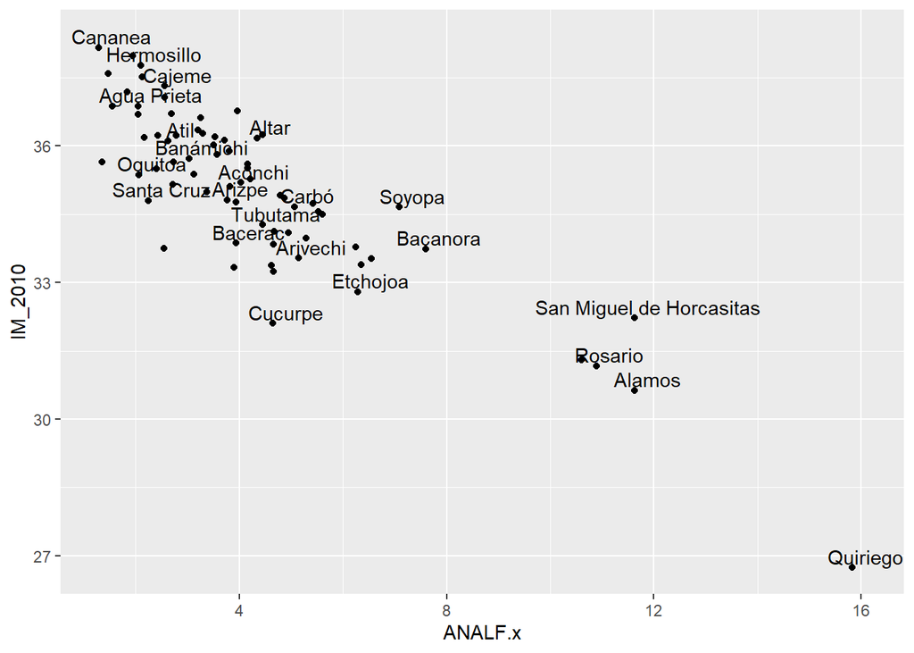

```r
ggplot(total_son, aes(x=ANALF.x, y=IM_2010)) +
  geom_point() + # Show dots
  geom_text(
    label=rownames(NOM_MUN),
    nudge_x = 0.25, nudge_y = 0.25,
    check_overlap = T )
```

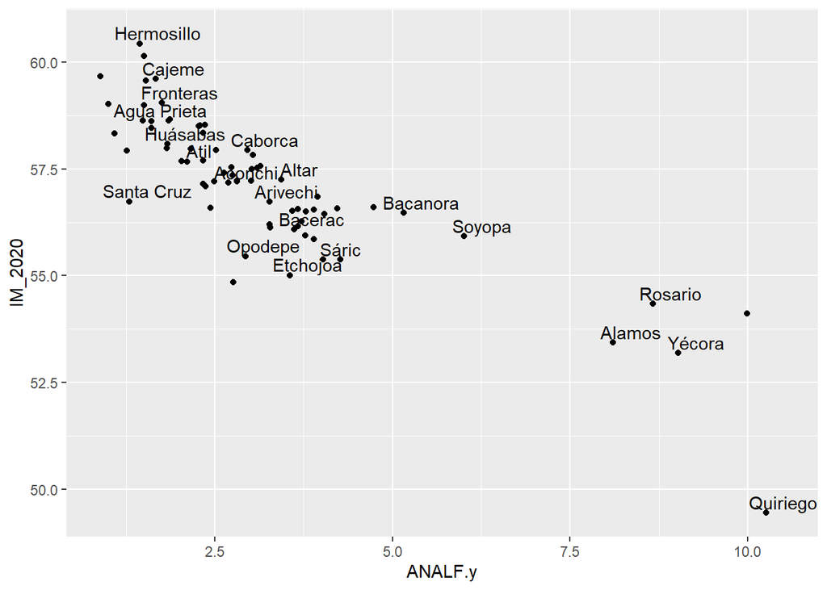

```r
library(ggplot2)


ggplot(total_son, aes(x=ANALF.y, y=IM_2020)) +
  geom_point() + # Show dots
  geom_text(
    label=rownames(NOM_MUN),
    nudge_x = 0.25, nudge_y = 0.25,
    check_overlap = T +
      theme(axis.text.x = element_text(angle = 90)))
```

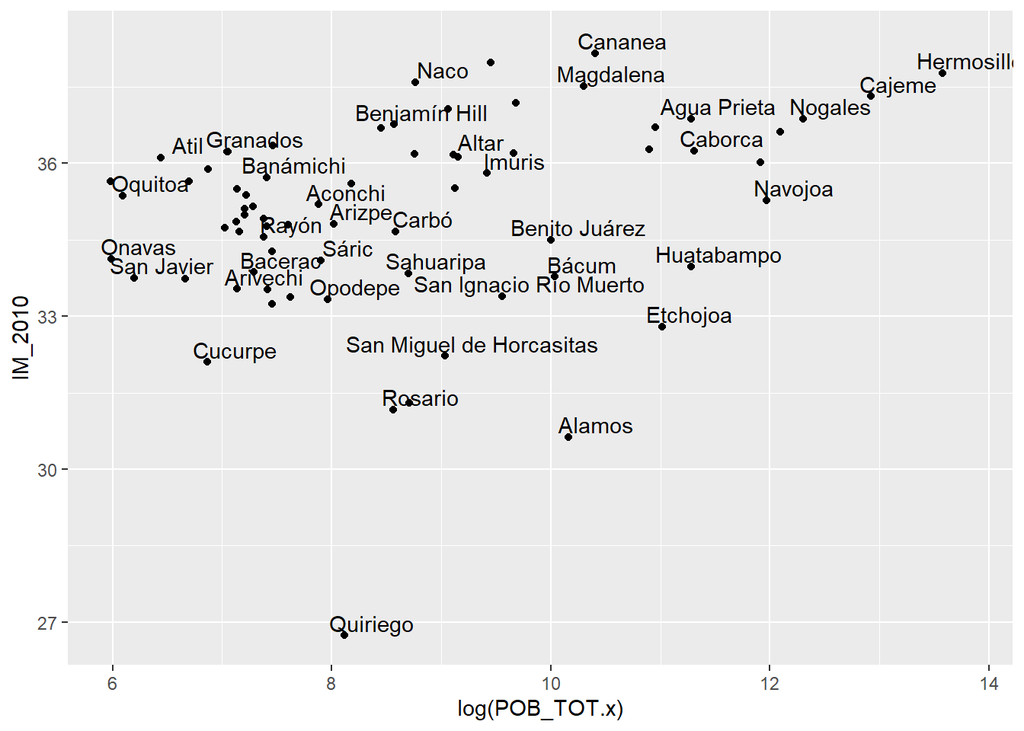

```r
ggplot(total_son, aes(x=log(POB_TOT.x), y=IM_2010)) +
  geom_point() + # Show dots
  geom_text(
    label=rownames(NOM_MUN),
    nudge_x = 0.25, nudge_y = 0.25,
    check_overlap = T )
```

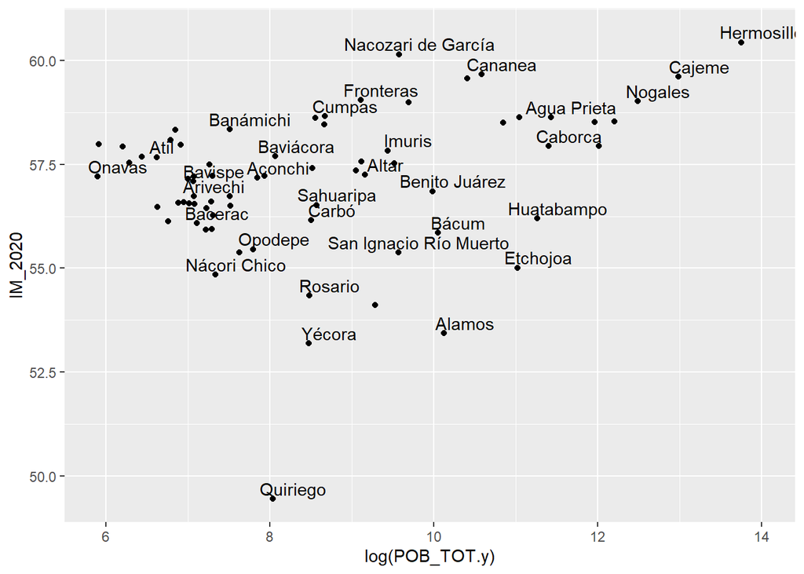

```r
ggplot(total_son, aes(x=log(POB_TOT.y), y=IM_2020)) +
  geom_point() + # Show dots
  geom_text(
    label=rownames(NOM_MUN),
    nudge_x = 0.25, nudge_y = 0.25,
    check_overlap = T )
```

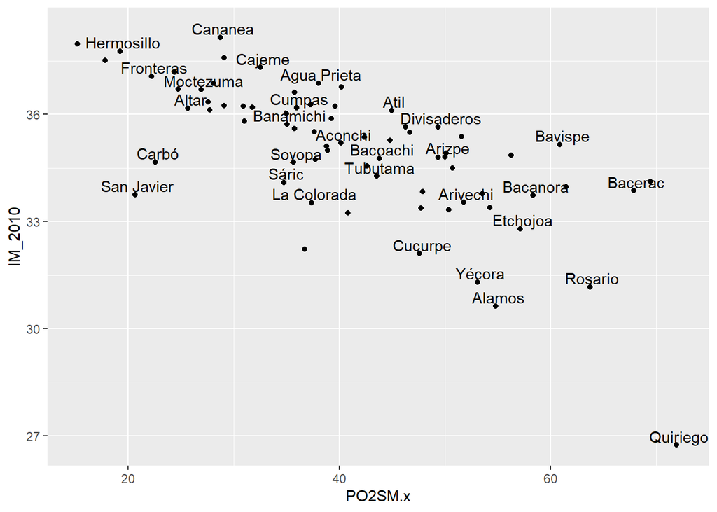

```r
ggplot(total_son, aes(x=PO2SM.x, y=IM_2010)) +
  geom_point() + # Show dots
  geom_text(
    label=rownames(NOM_MUN),
    nudge_x = 0.25, nudge_y = 0.25,
    check_overlap = T )
```

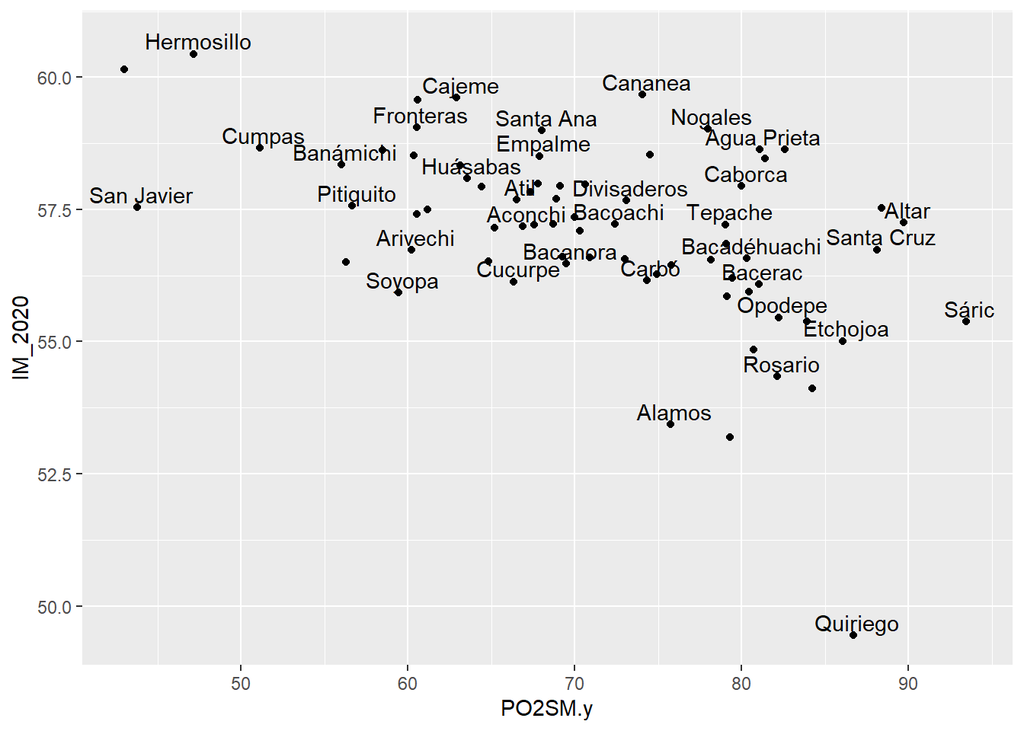

```r
ggplot(total_son, aes(x=PO2SM.y, y=IM_2020)) +
  geom_point() + # Show dots
  geom_text(
    label=rownames(NOM_MUN),
    nudge_x = 0.25, nudge_y = 0.25,
    check_overlap = T )
```

# **Heatmaps**

```r
# tag_2010 <-  data.frame(total_son$ANALF.x, total_son$SBASC.x, total_son$OVSDE.x, total_son$OVSEE.x, total_son$OVSAE.x, total_son$OVPT.x, total_son$VHAC.x, total_son$PL.5000.x, total_son$PO2SM.x, total_son$IM_2010)
#
# tag_2010

Matriz_2010 <- data.frame(total_son$ANALF.x, total_son$SBASC.x, total_son$OVSDE.x, total_son$OVSEE.x, total_son$OVSAE.x, total_son$OVPT.x, total_son$VHAC.x, total_son$PL.5000.x, total_son$PO2SM.x, total_son$IM_2010, row.names = total_son$NOM_MUN ,
                      check.rows = FALSE,
                      check.names = TRUE,
                      fix.empty.names = TRUE,
                      stringsAsFactors = FALSE)



Matriz_2010
```

```
##                               total_son.ANALF.x total_son.SBASC.x
## Aconchi                                4.025424          49.80400
## Agua Prieta                            2.050606          38.87123
## Alamos                                11.626377          54.87848
## Altar                                  4.349286          51.12905
## Arivechi                               5.139186          56.31692
## Arizpe                                 3.769401          52.57068
## Atil                                   2.620087          46.77293
## Bacadéhuachi                           4.872647          59.42350
## Bacanora                               7.603306          62.60643
## Bacerac                                3.938521          55.14918
## Bacoachi                               3.938907          54.42122
## Bácum                                  6.241143          46.32300
## Banámichi                              3.035413          45.33221
## Baviácora                              4.160247          50.49112
## Bavispe                                2.716298          61.93353
## Benjamín Hill                          3.968683          41.65993
## Caborca                                4.454981          42.54610
## Cajeme                                 2.560540          27.77950
## Cananea                                1.285993          29.63296
## Carbó                                  5.067568          55.90490
## La Colorada                            6.553585          64.34087
## Cucurpe                                4.644412          61.27168
## Cumpas                                 2.172061          43.73904
## Divisaderos                            1.349073          52.49078
## Empalme                                3.299626          35.38908
## Etchojoa                               6.282152          39.66273
## Fronteras                              2.554234          39.36290
## Granados                               2.424942          48.40665
## Guaymas                                3.508805          34.65103
## Hermosillo                             2.105482          26.20404
## Huachinera                             3.368421          61.05263
## Huásabas                               3.801170          50.32539
## Huatabampo                             5.282939          41.19561
## Huépac                                 2.780997          44.15558
## Imuris                                 3.569700          48.63526
## Magdalena                              2.125476          35.97954
## Mazatán                                3.815261          50.02551
## Moctezuma                              2.050381          37.16998
## Naco                                   1.469891          40.06209
```

[output cut: 310 more lines]

```
## Santa Ana                              24.38976          37.18824
## Santa Cruz                             49.33921          34.80005
## Sáric                                  34.75533          34.09590
## Soyopa                                 35.65022          34.65562
## Suaqui Grande                          37.73087          34.72796
## Tepache                                51.56794          35.37984
## Trincheras                             40.79861          33.23697
## Tubutama                               43.53448          34.26751
## Ures                                   37.63234          35.51241
## Villa Hidalgo                          27.57848          36.34041
## Villa Pesqueira                        46.66667          35.50274
## Yécora                                 53.07770          31.30394
## General Plutarco Elías Calles          31.78836          36.19429
## Benito Juárez                          50.73099          34.49995
## San Ignacio Río Muerto                 54.23596          33.39141
```

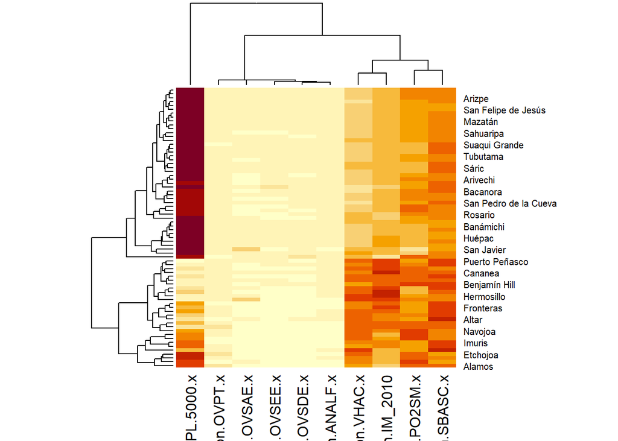

```r
Heatmap_2010 <- as.matrix(Matriz_2010)

heatmap(Heatmap_2010)
```

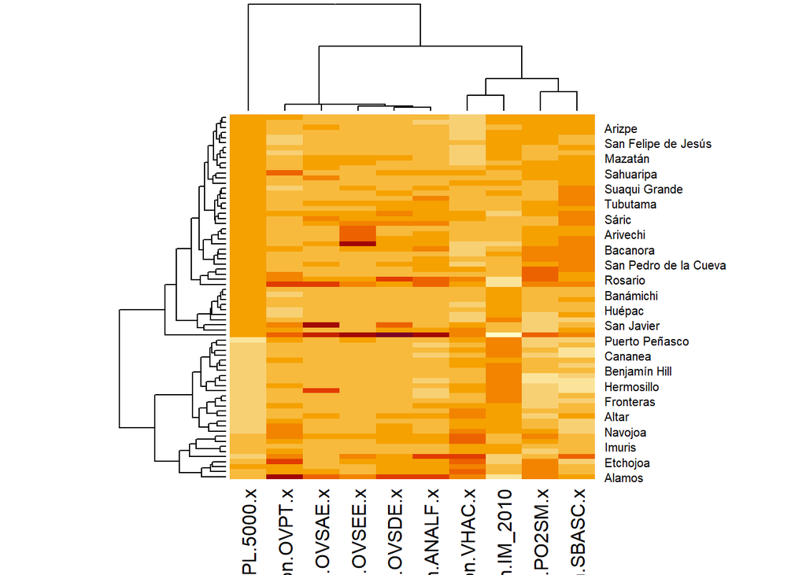

```r
heatmap(Heatmap_2010, scale="column")
```

```r
Matriz_2020 <- data.frame(total_son$ANALF.y, total_son$SBASC.y, total_son$OVSDE.y, total_son$OVSEE.y, total_son$OVSAE.y, total_son$OVPT.y, total_son$VHAC.y, total_son$PL.5000.y, total_son$PO2SM.y, total_son$IM_2020, row.names = total_son$NOM_MUN ,
                      check.rows = FALSE,
                      check.names = TRUE,
                      fix.empty.names = TRUE,
                      stringsAsFactors = FALSE)



Matriz_2020
```

```
##                               total_son.ANALF.y total_son.SBASC.y
## Aconchi                               2.6917217          37.12544
## Agua Prieta                           1.4882027          26.01952
## Alamos                                8.1075269          41.65663
## Altar                                 3.4339230          35.08974
## Arivechi                              3.2657658          45.91265
## Arizpe                                2.8110599          41.45158
## Atil                                  2.0325203          33.75947
## Bacadéhuachi                          4.2199488          50.51151
## Bacanora                              5.1546392          53.43643
## Bacerac                               3.6144578          43.59255
## Bacoachi                              3.0094583          43.07825
## Bácum                                 3.8964765          35.25205
## Banámichi                             2.3340627          29.10284
## Baviácora                             2.3349436          37.60064
## Bavispe                               2.3640662          54.25532
## Benjamín Hill                         2.6315789          30.54802
## Caborca                               2.9541690          30.24268
## Cajeme                                1.6634109          18.88167
## Cananea                               0.8873768          17.52734
## Carbó                                 3.6663868          40.89001
## La Colorada                           3.7774725          49.31319
## Cucurpe                               3.2738095          45.98214
## Cumpas                                1.8650089          29.94226
## Divisaderos                           2.1052632          39.29825
## Empalme                               2.2710088          26.42247
## Etchojoa                              3.5580892          27.66049
## Fronteras                             1.7518939          23.64372
## Granados                              2.1573604          38.07107
## Guaymas                               2.2901670          24.32245
## Hermosillo                            1.4397599          17.56277
## Huachinera                            3.8961039          46.10390
## Huásabas                              1.8309859          35.91549
## Huatabampo                            3.2685363          27.92749
## Huépac                                1.0899183          33.87755
## Imuris                                3.0387047          35.41089
## Magdalena                             1.5284112          25.20442
## Mazatán                               2.3333333          40.00000
## Moctezuma                             1.6064257          24.27209
## Naco                                  1.6029593          28.02333
```

[output cut: 310 more lines]

```
## Santa Ana                              68.04734          58.99521
## Santa Cruz                             88.10642          56.73902
## Sáric                                  93.44692          55.37841
## Soyopa                                 59.42275          55.93019
## Suaqui Grande                          72.98475          56.56874
## Tepache                                79.00552          57.21702
## Trincheras                             75.77982          56.44951
## Tubutama                               80.46422          55.94143
## Ures                                   69.99453          57.35414
## Villa Hidalgo                          61.18421          57.50087
## Villa Pesqueira                        70.89109          56.59460
## Yécora                                 79.28634          53.18762
## General Plutarco Elías Calles          88.37833          57.53339
## Benito Juárez                          79.08897          56.85480
## San Ignacio Río Muerto                 83.92756          55.37436
```

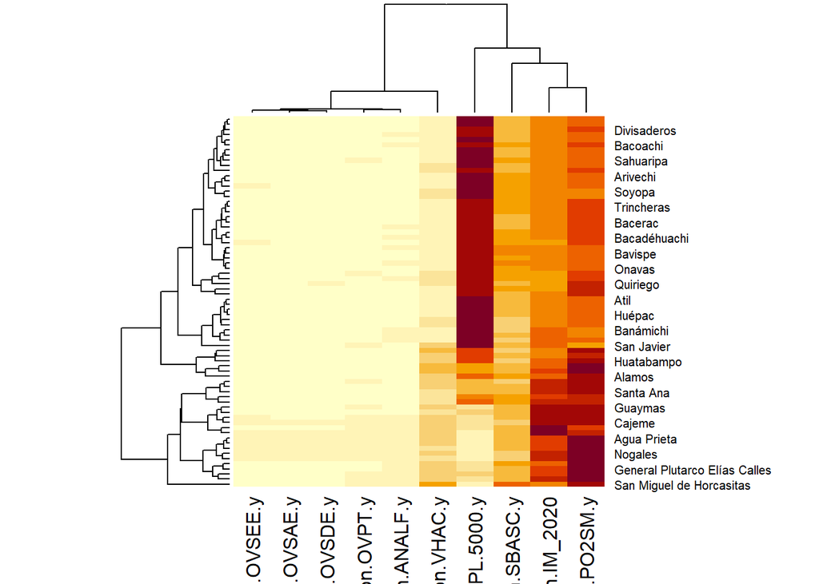

```r
Heatmap_2020 <- as.matrix(Matriz_2020)

heatmap(Heatmap_2020)
```

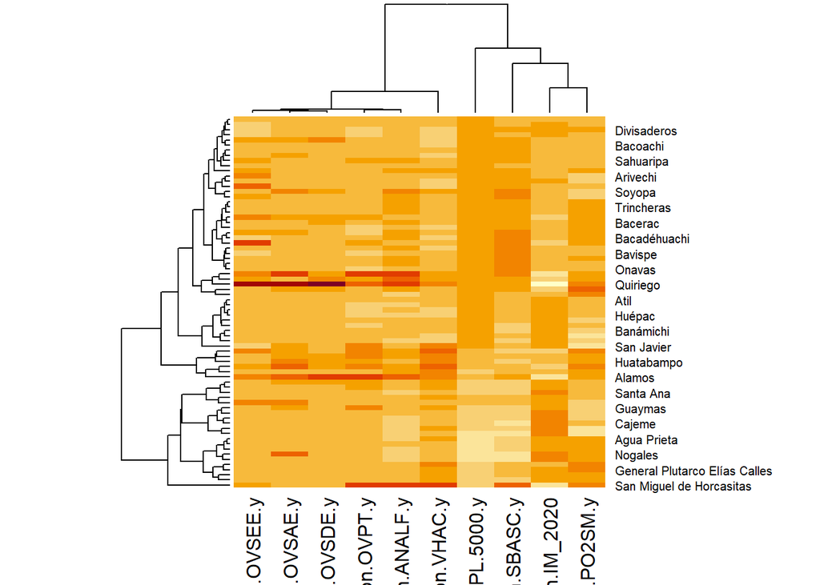

```r
heatmap(Heatmap_2020, scale="column")
```

# **Definición de objetivo y KPI**

A partir de los datos de marginación municipal en Sonora, años 2010 y 2020, es posible conocer el cambio en valores de marginación y sus componentes para saber qué municipios man crecido más que otros en estas variables, cuáles han permanecido igual, en qué municipios se refleja un mejor o peor escenario salaria.

Los *Key performance indicators* establecidos fueron las tasas de crecimiento de los Índices de Marginación y sus componentes. Sin embargo, considerando la correlación de algunas de estas variables, los KPI’s más importantes son: IM_TC, POB_TC, ANALF_TC y PO2SM_TC.

```r
total_son <- total_son %>%
  #select(IM_2010) %>%
  arrange(CVE_MUN) %>%
  #group_by(county) %>%
  mutate(IM_TC = ((IM_2020/IM_2010)-1)*100) %>%
  mutate(IMN_TC = ((IMN_2020/IMN_2010)-1)*100) %>%
  mutate(POB_TC = ((POB_TOT.y/POB_TOT.x)-1)*100) %>%
  mutate(ANALF_TC = ((ANALF.y/ANALF.x)-1)*100) %>%
  mutate(SBASC_TC = ((SBASC.y/SBASC.x)-1)*100) %>%
  mutate(OVSDE_TC = ((OVSDE.y/OVSDE.x)-1)*100) %>%
  mutate(OVSEE_TC = ((OVSEE.y/OVSEE.x)-1)*100) %>%
  mutate(OVSAE_TC = ((OVSAE.y/OVSAE.x)-1)*100) %>%
  mutate(OVPT_TC = ((OVPT.y/OVPT.x)-1)*100) %>%
  mutate(VHAC_TC = ((VHAC.y/VHAC.x)-1)*100) %>%
  mutate(PL.5000_TC = ((PL.5000.y/PL.5000.x)-1)*100) %>%
  mutate(PO2SM_TC = ((PO2SM.y/PO2SM.x)-1)*100) %>%

  ungroup()

total_son
```

```
## # A tibble: 72 x 42
##    CVE_ENT NOM_ENT CVE_MUN NOM_MUN     POB_TOT.x ANALF.x SBASC.x OVSDE.x OVSEE.x
##    <chr>   <chr>   <chr>   <chr>           <dbl>   <dbl>   <dbl>   <dbl>   <dbl>
##  1 26      Sonora  26001   Aconchi          2637    4.03    49.8   1.87    0.304
##  2 26      Sonora  26002   Agua Prieta     79138    2.05    38.9   0.361   2.97
##  3 26      Sonora  26003   Alamos          25848   11.6     54.9  12.4     7.28
##  4 26      Sonora  26004   Altar            9049    4.35    51.1   3.04    1.01
##  5 26      Sonora  26005   Arivechi         1253    5.14    56.3   2.78   10.4
##  6 26      Sonora  26006   Arizpe           3037    3.77    52.6   2.52    3.21
##  7 26      Sonora  26007   Atil              625    2.62    46.8   0.48    0.8
##  8 26      Sonora  26008   Bacadéhuac~      1252    4.87    59.4   2.49    0.240
##  9 26      Sonora  26009   Bacanora          784    7.60    62.6   4.09    4.61
## 10 26      Sonora  26010   Bacerac          1467    3.94    55.1   1.57    3.23
## # ... with 62 more rows, and 33 more variables: OVSAE.x <dbl>, OVPT.x <dbl>,
## #   VHAC.x <dbl>, PL.5000.x <dbl>, PO2SM.x <dbl>, IM_2010 <dbl>, GM_2010 <chr>,
## #   IMN_2010 <dbl>, POB_TOT.y <dbl>, ANALF.y <dbl>, SBASC.y <dbl>,
## #   OVSDE.y <dbl>, OVSEE.y <dbl>, OVSAE.y <dbl>, OVPT.y <dbl>, VHAC.y <dbl>,
## #   PL.5000.y <dbl>, PO2SM.y <dbl>, IM_2020 <dbl>, GM_2020 <chr>,
## #   IMN_2020 <dbl>, IM_TC <dbl>, IMN_TC <dbl>, POB_TC <dbl>, ANALF_TC <dbl>,
## #   SBASC_TC <dbl>, OVSDE_TC <dbl>, OVSEE_TC <dbl>, OVSAE_TC <dbl>, ...
```

A continuación, se presentan las gráficas para visualizar el crecimiento de los principales KPY’s:

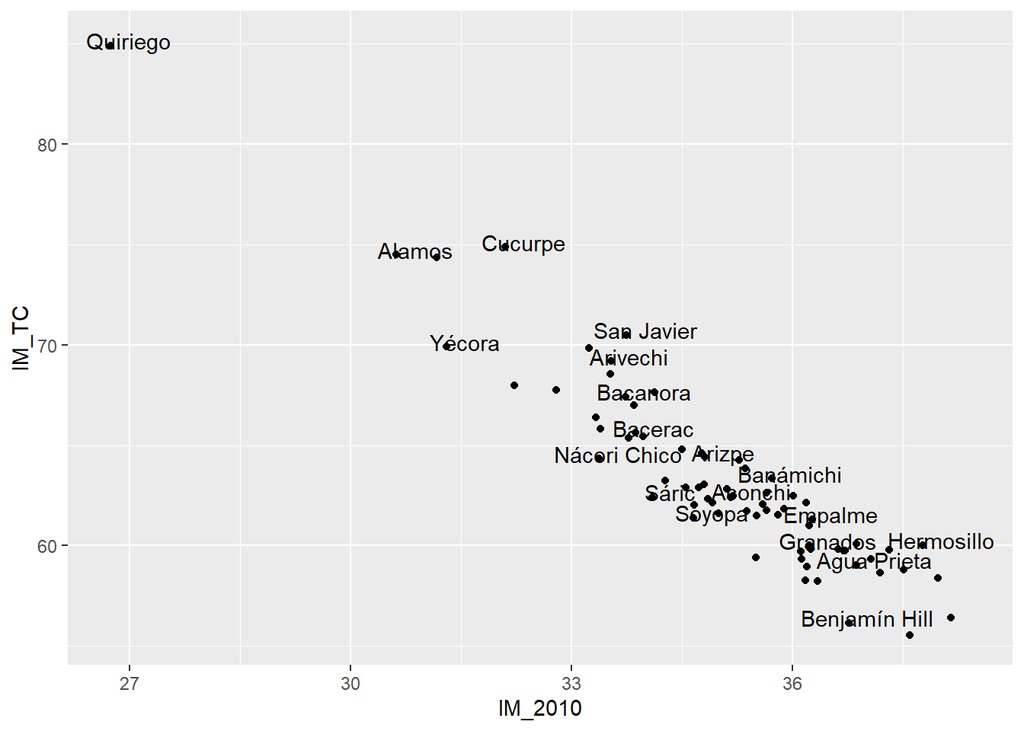

```r
ggplot(total_son, aes(x=IM_2010, y=IM_TC)) +
  geom_point() + # Show dots
  geom_text(
    label=rownames(NOM_MUN),
    nudge_x = 0.25, nudge_y = 0.25,
    check_overlap = T )
```

```r
# Para verificar la situación general de Quiriego, se aplica el siguiente comando, que llama al renglón con la informacióin de dicho municipio del data frame correspondiente.
total_son[total_son$NOM_MUN == 'Quiriego',]
```

```
## # A tibble: 1 x 42
##   CVE_ENT NOM_ENT CVE_MUN NOM_MUN  POB_TOT.x ANALF.x SBASC.x OVSDE.x OVSEE.x
##   <chr>   <chr>   <chr>   <chr>        <dbl>   <dbl>   <dbl>   <dbl>   <dbl>
## 1 26      Sonora  26049   Quiriego      3356    15.8    63.6    24.5    21.4
## # ... with 33 more variables: OVSAE.x <dbl>, OVPT.x <dbl>, VHAC.x <dbl>,
## #   PL.5000.x <dbl>, PO2SM.x <dbl>, IM_2010 <dbl>, GM_2010 <chr>,
## #   IMN_2010 <dbl>, POB_TOT.y <dbl>, ANALF.y <dbl>, SBASC.y <dbl>,
## #   OVSDE.y <dbl>, OVSEE.y <dbl>, OVSAE.y <dbl>, OVPT.y <dbl>, VHAC.y <dbl>,
## #   PL.5000.y <dbl>, PO2SM.y <dbl>, IM_2020 <dbl>, GM_2020 <chr>,
## #   IMN_2020 <dbl>, IM_TC <dbl>, IMN_TC <dbl>, POB_TC <dbl>, ANALF_TC <dbl>,
## #   SBASC_TC <dbl>, OVSDE_TC <dbl>, OVSEE_TC <dbl>, OVSAE_TC <dbl>, ...
```

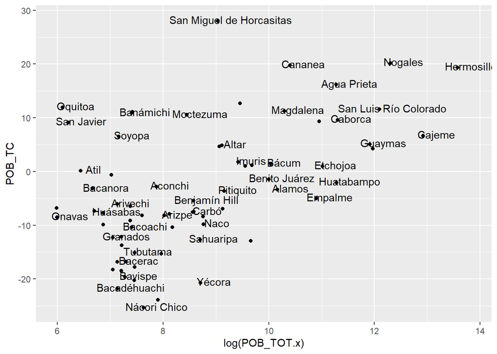

```r
ggplot(total_son, aes(x=log(POB_TOT.x), y=POB_TC)) +
  geom_point() + # Show dots
  geom_text(
    label=rownames(NOM_MUN),
    nudge_x = 0.25, nudge_y = 0.25,
    check_overlap = T )
```

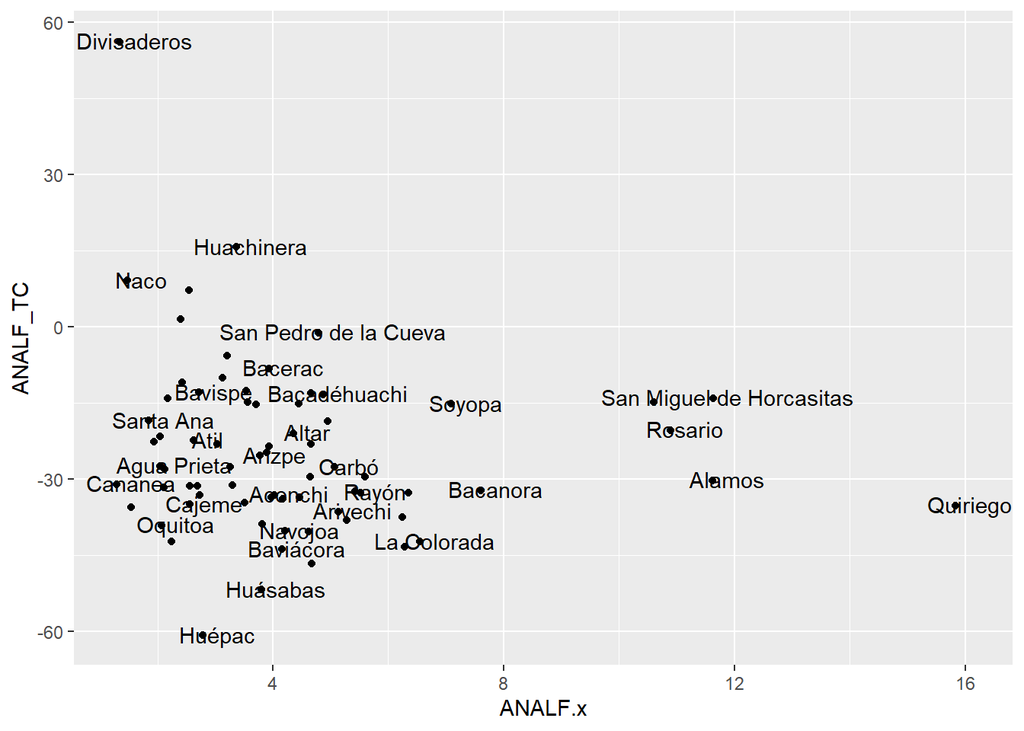

```r
ggplot(total_son, aes(x=ANALF.x, y=ANALF_TC)) +
  geom_point() + # Show dots
  geom_text(
    label=rownames(NOM_MUN),
    nudge_x = 0.25, nudge_y = 0.25,
    check_overlap = T )
```

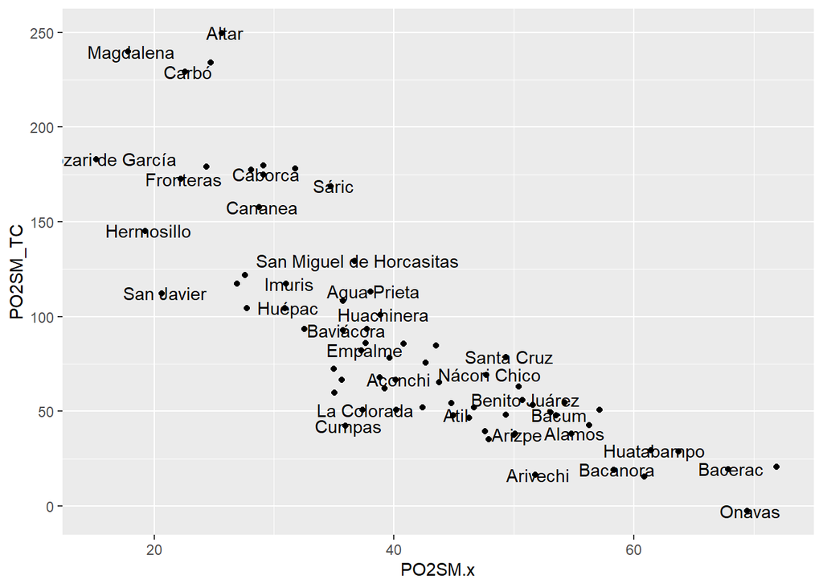

```r
ggplot(total_son, aes(x=PO2SM.x, y=PO2SM_TC)) +
  geom_point() + # Show dots
  geom_text(
    label=rownames(NOM_MUN),
    nudge_x = 0.25, nudge_y = 0.25,
    check_overlap = T )
```

# **Conclusiones**

El proceso descrito previamente es sólamente el primer paso no sólo de este, sino cualquier proyecto de ciencia de datos. La obtención automatizada de datos, a través de enlaces (como fue caso presente) o APIs, facilita y democratiza el uso de scripts o modelos para la comunidad involucrada en la ciencia de datos u otras disciplinas de investigación. El uso de comandos, tales como *left_join*, es fundamental para generar bases de datos *tidy*¨, u ordenadas. El caso descrito fue relativament sencillo por ser datos provenientes de una fuente oficial del gobienro federal, pero el escenario común es encontrar bases de datos incopletas, con valores nulos (NA), desactualizadas y sin orden de columnas. En este sentido, es indispensable tener en consideración comandos para limpiar una base de datos, independientemente del lenguaje de programación. Por último, un diccionario de datos es parte fundamental para conocer el fenómeno a analizar. Sin éste, carece de sentido la interpretación del modelo o análisis que parte de los datos.

Los KPI’s fueron las tasas de crecimientol índice de marginación, junto con sus componentes, pero se eligieron principalmente cuatro indicadores: la tasa de crecimiento del índice de marginación (IM_TC), la tasa de crecimiento de la población (POB_TC), la tasa de crecimiento del porcentaje de población analfabeta mayor a 15 años (ANALF_TC) y la tasa de crecimiento del porcentaje de personas economicamente ocupadas que ganan hasta dos salarios mínimps (PO2SM_TC). La razón por la cual se eligieron estos indicadores fue su mayor relevancia respecto a los demás para definir el grado de marginación municiapal, pues varios de los componentes del IM están autocorrelacionados.

A partir de esta información, será posible generar un dashboard en línea que refleje el cambio en el grado de marginación municipal en Sonora, entre 2010 y 2020.

# **Bibliografía**

- Comisión Nacional de Población (CONAPO). (2020). Indicadores de marginación. gob.mx. Retrieved October 16, 2022, from [gob](https://www.gob.mx/conapo/documentos/indices-de-marginacion-2020-284372)
- Holtz, Y. (n.d.). Add text labels with ggplot2. Retrieved November 2, 2022, from [r-graph-gallery.com](https://r-graph-gallery.com/275-add-text-labels-with-ggplot2.html)
- Holtz, Y. (n.d.-b). Building heatmap with R. Retrieved November 2, 2022, from [r-graph-gallery.com](https://r-graph-gallery.com/215-the-heatmap-function.html)
- How to calculate growth rate from two different columns to a new column with dplyr? (2021, February 19). [Stack Overflow](https://stackoverflow.com/questions/66282209/how-to-calculate-growth-rate-from-two-different-columns-to-a-new-column-with-dpl)
- how to insert image from url in markdown. (2015, March 7). [Stack Overflow](https://stackoverflow.com/questions/28912868/how-to-insert-image-from-url-in-markdown)
- *Left join only selected columns in R with the merge() function*. (2014, June 12). Stack Overflow. Retrieved October 16, 2022, from [stackoverflow](https://stackoverflow.com/questions/24191497/left-join-only-selected-columns-in-r-with-the-merge-function)
- Spar User: NNK. (2022, July 10). [Spark by {Examples}](https://sparkbyexamples.com/r-programming/select-rows-in-r/)
- *Read Excel file from a URL using the readxl package*. (2016, December 28). Stack Overflow. Retrieved October 13, 2022, from [stackoverflow](https://stackoverflow.com/questions/41368628/read-excel-file-from-a-url-using-the-readxl-package)
- Spark by Examples. (2022, July 10). How to Select Rows in R with Examples. Retrieved October 16, 2022, from [sparkbyexmaples](https://sparkbyexamples.com/r-programming/select-rows-in-r/)